# Análisis Avanzado de Datos: Taller 1

DAVID SANTIAGO GÓMEZ LEÓNJUAN ESTEBAN GONZALEZ SOTO

2026-03-08

# 0. Preámbulo

```r
library(glmnet)
library(doParallel)
library(ggplot2)   # Para gráficos avanzados
library(broom)     # Para limpiar objetos de modelos
library(dplyr)     # Para manipulación de datos
```

# 0.1. Cargar los datos

```r
datos <- read.csv("taller1.txt")
```

# 0.2. Contexto Analítico

El presente estudio analiza el perfil genómico de 1200 líneas celulares con el objetivo de identificar cuáles de los 5000 genes secuenciados son relevantes para predecir la efectividad de un tratamiento anticancerígeno (variable respuesta continua).

# 1. Análisis de Multicolinealidad Estructural (p > n)

Sí, existe una multicolinealidad estructural severa. El conjunto de datos presenta un escenario de alta dimensionalidad donde el número de predictores ($p = 5000$ genes) excede estrictamente el número de observaciones ($n = 1200$ líneas celulares). Matemáticamente, esto implica que la matriz de diseño $X$ no tiene rango completo, haciendo que la matriz $X^TX$ sea singular (no invertible). En consecuencia, el estimador de Mínimos Cuadrados Ordinarios (MCO) carece de una solución única y colapsa, haciendo estrictamente imperativo el uso de métodos de regularización (como Ridge o LASSO) para inducir sesgo y reducir la varianza.

# 2. Partición del Conjunto de Datos y Preprocesamiento

Para evaluar la capacidad de generalización del modelo, se realiza una partición aleatoria reteniendo la semilla (`set.seed(18)`) para garantizar la reproducibilidad.

- **Entrenamiento:** 1000 líneas celulares.
- **Prueba:** 200 líneas celulares.

**Nota Metodológica:** Para evitar el “Data Leakage” (fuga de información), la estandarización de las variables predictoras se realiza calculando la media y desviación estándar *únicamente* sobre el conjunto de entrenamiento, aplicando luego estos mismos parámetros al conjunto de prueba.

```r
#Separar variables predictoras
X <- as.matrix(datos[, -1])
Y <- datos$y
```

```r
#Fijamos la semilla para garantizar la reproducibilidad
set.seed(18)
```

```r
#Generamos 1000 índices aleatorios del 1 al 1200
indices_entrenamiento <- sample(1:nrow(X), 1000)
```

```r
#Creamos los conjuntos de Entrenamiento
X_train <- X[indices_entrenamiento, ]
Y_train <- Y[indices_entrenamiento]
```

Antes de generar los conjuntos de prueba, aplicamos la estandarización de los datos, de forma externa al dado por la libreria glmnet.

```r
#La estandarizacion se realiza basada en los datos
# de entrenamiento para evitar data leakage y #sesgar el poder predictivo del modelo

mean_train <- apply(X_train,2, mean)
sd_train <- apply(X_train, 2, sd)


#Estandarizamos loa conjuntos de entrenamiento

X_train <- scale(X_train, center = mean_train, scale= sd_train)
```

```r
#Creamos los conjuntos de Prueba

X_test <- X[-indices_entrenamiento, ]
Y_test <- Y[-indices_entrenamiento]


# Se estandariza el conjunto de entrenamiento #basado en los mismos parametros
#(Crucial para evaluacion insesgada)
X_test <- scale(X_test, center = mean_train, scale = sd_train)

# Estandarizamos todo el dataset para la evaluacion #en el Punto 6
X_scaled <- scale(X, center = apply(X, 2, mean), scale = apply(X, 2, sd))
```

# 3. Optimización de Hiperparámetros mediante Validación Cruzada

Para determinar los valores óptimos de penalización ($\lambda_r$ para Ridge y $\lambda_l$ para LASSO), se utiliza **Validación Cruzada de 10 particiones (10-fold CV)** sobre los 1000 datos de entrenamiento. Este método es el más apropiado ya que evalúa el desempeño en subconjuntos de retención (validación externa al ajuste interno), minimizando el Error Cuadrático Medio (ECM).

Se seleccionará el hiperparámetro bajo la **Regla de 1 Error Estándar (`lambda.1se`)** para favorecer el modelo más parsimonioso (aquel que penaliza más variables sin perder capacidad predictiva significativa).

```r
set.seed(18)

num_cores = detectCores()-1

registerDoParallel(cores = num_cores)

#Validación cruzada para Regresión Ridge (alpha = 0).

cv_ridge <- cv.glmnet(x = X_train, y = Y_train, alpha = 0, nfolds = 10)
```

```r
lambda_r <- cv_ridge$lambda.1se
cat("El valor optimo de lambda_r (Ridge) es:", lambda_r, "\n")
```

```
## El valor optimo de lambda_r (Ridge) es: 38.50644
```

```r
set.seed(18)

#Validación cruzada para Regresión Lasso (alpha = 1)
cv_lasso <- cv.glmnet(x = X_train, y = Y_train, alpha = 1, nfolds = 10)
```

```r
lambda_l <- cv_lasso$lambda.1se
cat("El valor óptimo de lambda_l (Lasso) es:", lambda_l, "\n")
```

```
## El valor óptimo de lambda_l (Lasso) es: 0.1071464
```

# 4. Entrenamiento de Modelos Penalizados

Utilizando los hiperparámetros óptimos $\lambda_{1se}$ calculados en la validación cruzada, se procede a ajustar los modelos Ridge ($\alpha = 0$) y LASSO ($\alpha = 1$) exclusivamente sobre el conjunto de 1000 observaciones de entrenamiento.

Ajuste del modelo de regresión Ridge (alpha = 0) con el lambda estimado:

```r
modelo_ridge <- glmnet(x = X_train, y = Y_train, alpha = 0, lambda = lambda_r)
```

Ajuste del modelo de regresión Lasso (alpha = 1) con el lambda estimado:

```r
modelo_lasso <- glmnet(x = X_train, y = Y_train, alpha = 1, lambda = lambda_l)
```

# 5. Evaluación y Selección del Modelo Predictivo

Para determinar el modelo más apropiado para propósitos predictivos en el mundo real, se evalúa el desempeño basándose **estrictamente en el Error Cuadrático Medio (ECM) sobre los 200 datos de prueba**, tal como se requiere metodológicamente. Además, se realiza un diagnóstico de residuos para descartar sesgos no lineales.

Calcular las predicciones para el conjunto de prueba usando Ridge:

```r
pred_ridge <- predict(modelo_ridge, s = lambda_r, newx = X_test)
```

Calcular el Error Cuadrático Medio (ECM) para Ridge:

```r
ecm_ridge <- mean((Y_test - pred_ridge)^2)
cat("El ECM de Ridge en los datos de prueba es:", ecm_ridge, "\n")
```

```
## El ECM de Ridge en los datos de prueba es: 18.37496
```

Calcular las predicciones para el conjunto de prueba usando Lasso:

```r
pred_lasso <- predict(modelo_lasso, s = lambda_l, newx = X_test)
```

Calcular el Error Cuadrático Medio (ECM) para Lasso:

```r
ecm_lasso <- mean((Y_test - pred_lasso)^2)
cat("El ECM de Lasso en los datos de prueba es:", ecm_lasso, "\n")
```

```
## El ECM de Lasso en los datos de prueba es: 1.349881
```

Determinar el modelo más apropiado:

```r
# Lógica Diagnóstica y Visualización de Desempeño
if(ecm_lasso < ecm_ridge) {
  cat("\nConclusión: El modelo LASSO es el mas apropiado (ECM:", ecm_lasso, ").\n")
  alpha_seleccionado <- 1
  lambda_seleccionado <- lambda_l
  predicciones_finales <- pred_lasso
} else {
  cat("\nConclusión: El modelo RIDGE es el mas apropiado (ECM:", ecm_ridge, ").\n")
  alpha_seleccionado <- 0
  lambda_seleccionado <- lambda_r
  predicciones_finales <- pred_ridge
}
```

```
##
## Conclusión: El modelo LASSO es el mas apropiado (ECM: 1.349881 ).
```

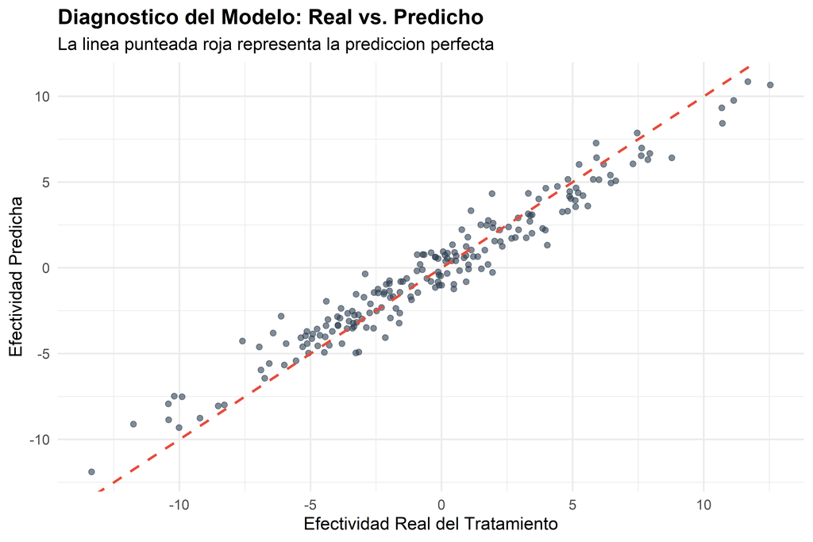

```r
# Crear un DataFrame para ggplot
resultados_test <- data.frame(Real = Y_test, Predicho = as.numeric(predicciones_finales))

# Gráfico de Real vs Predicho
ggplot(resultados_test, aes(x = Real, y = Predicho)) +
  geom_point(alpha = 0.6, color = "#2c3e50", size = 2) +
  geom_abline(intercept = 0, slope = 1, color = "#e74c3c", linetype = "dashed", size = 1) +
  theme_minimal(base_size = 14) +
  labs(title = "Diagnostico del Modelo: Real vs. Predicho",
       subtitle = "La linea punteada roja representa la prediccion perfecta",
       x = "Efectividad Real del Tratamiento",
       y = "Efectividad Predicha") +
  theme(plot.title = element_text(face = "bold"))
```

```r
# DIAGNÓSTICO PROFUNDO: Sobreajuste y No-linealidad
library(ggplot2)

# 1. Prueba de Sobreajuste (Train vs Test)
pred_train_lasso <- predict(modelo_lasso, s = lambda_l, newx = X_train)
ecm_train_lasso <- mean((Y_train - pred_train_lasso)^2)

cat("\n--- PRUEBA DE REALIDAD ---\n")
```

```
##
## --- PRUEBA DE REALIDAD ---
```

```r
cat("ECM en Entrenamiento (Memoria):", ecm_train_lasso, "\n")
```

```
## ECM en Entrenamiento (Memoria): 1.225011
```

```r
cat("ECM en Prueba (Realidad):", ecm_lasso, "\n")
```

```
## ECM en Prueba (Realidad): 1.349881
```

```r
cat("Diferencia:", ecm_lasso - ecm_train_lasso, "\n\n")
```

```
## Diferencia: 0.1248698
```

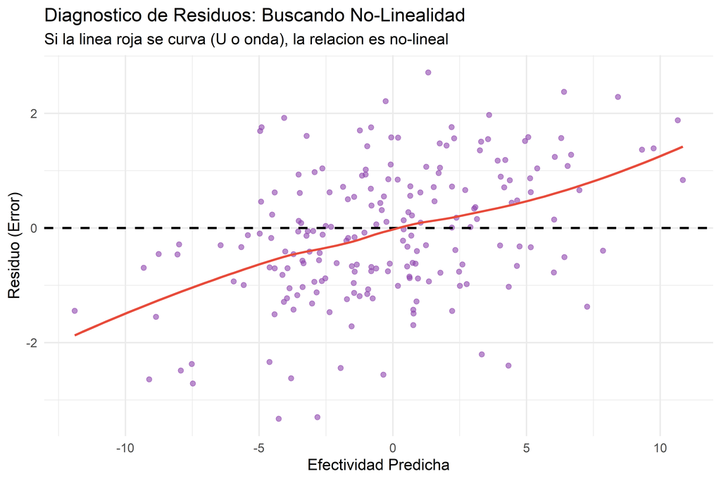

```r
# 2. Prueba de No-Linealidad (Analisis de Residuos)
# Calculamos los residuos (Error = Real - Predicción)
residuos_test <- Y_test - as.numeric(pred_lasso)
df_residuos <- data.frame(Predicho = as.numeric(pred_lasso), Residuos = residuos_test)

# Grafico de Residuos vs Valores Predichos
ggplot(df_residuos, aes(x = Predicho, y = Residuos)) +
  geom_point(alpha = 0.6, color = "#8e44ad", size = 2) +
  geom_hline(yintercept = 0, color = "black", linetype = "dashed", size = 1) +
  geom_smooth(method = "loess", color = "#e74c3c", se = FALSE) + # Línea de tendencia curva
  theme_minimal(base_size = 14) +
  labs(title = "Diagnostico de Residuos: Buscando No-Linealidad",
       subtitle = "Si la linea roja se curva (U o onda), la relacion es no-lineal",
       x = "Efectividad Predicha",
       y = "Residuo (Error)")
```

# 6. Ajuste del Modelo Definitivo (Full Dataset)

Habiendo seleccionado el modelo y su respectivo parámetro de regularización, se procede a re-entrenar el algoritmo utilizando la totalidad de la información disponible (1200 líneas celulares). Esto maximiza el aprendizaje del modelo final antes de extraer la firma genómica.

```r
modelo_final <- glmnet(x = X, y = Y, alpha = alpha_seleccionado, lambda = lambda_seleccionado)

cat("El modelo final ha sido ajustado exitosamente con los 1200 datos.\n")
```

```
## El modelo final ha sido ajustado exitosamente con los 1200 datos.
```

```r
coef_final <- coef(modelo_final, s=lambda_seleccionado)

genes_activos <- which(coef_final != 0)

#Excluimos el intercepto

n_genes <- length(genes_activos)-1

cat("El modelo final selecciono", n_genes, "genes de los 5000 originales.\n")
```

```
## El modelo final selecciono 24 genes de los 5000 originales.
```

```r
importancia <- as.matrix(coef_final[genes_activos, , drop=FALSE])
print(head(importancia[order(abs(importancia), decreasing = TRUE), , drop=FALSE], 11))
```

```
##     s=0.1071464
## V17   0.9517346
## V11   0.9329891
## V5    0.9235741
## V6    0.9193399
## V7    0.9113368
## V18   0.9075038
## V2    0.9050745
## V19   0.9026187
## V14   0.9012530
## V15   0.8923493
## V20   0.8887093
```

# 7. Geometría de la Regularización: Trazas de Coeficientes

El siguiente gráfico ilustra cómo el modelo contrae los 5000 coeficientes a medida que aumenta la fuerza de la penalización $\lambda$. Se ha implementado una jerarquía visual para destacar los 5 genes con mayor peso predictivo frente al ruido biológico de fondo que es progresivamente anulado.

Ajustamos el modelo con todos los datos y el alpha seleccionado para obtener la ruta completa.

A partir de lo anterior generamos la gráfica de las trazas.

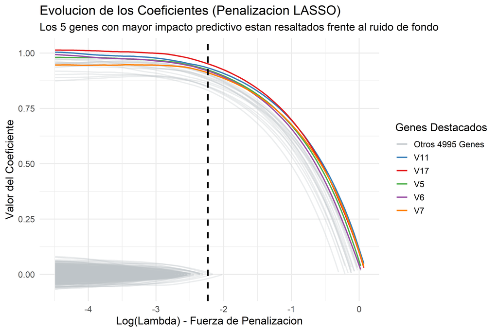

```r
# Gráfico de Trazas con Jerarquía Visual
library(dplyr)
library(ggplot2)
library(broom)

# 1. Ajustar el modelo para las trazas
modelo_trazas <- glmnet(x = X, y = Y, alpha = alpha_seleccionado)
df_trazas <- tidy(modelo_trazas)

# 2. Identificar los Top 5 genes más fuertes (en el lambda seleccionado)
coef_final <- coef(modelo_final, s = lambda_seleccionado)
importancia <- as.matrix(coef_final)
df_coef_temp <- data.frame(Gen = rownames(importancia), Coeficiente = as.numeric(importancia))

top_5_genes <- df_coef_temp %>%
  filter(Gen != "(Intercept)") %>%
  mutate(AbsCoef = abs(Coeficiente)) %>%
  arrange(desc(AbsCoef)) %>%
  head(5) %>%
  pull(Gen)

# 3. Crear una nueva columna para el color (Destacar Top 5, apagar el resto)
df_trazas <- df_trazas %>%
  filter(term != "(Intercept)") %>%
  mutate(Categoria = ifelse(term %in% top_5_genes, term, "Otros 4995 Genes"))

# 4. Generar el gráfico pulido
ggplot(df_trazas, aes(x = log(lambda), y = estimate, group = term, color = Categoria, alpha = Categoria)) +
  geom_line(size = 0.8) +
  # Escalas manuales para forzar que 'Otros' sea gris y transparente
  scale_color_manual(values = c(setNames(RColorBrewer::brewer.pal(5, "Set1"), top_5_genes), "Otros 4995 Genes" = "#bdc3c7")) +
  scale_alpha_manual(values = c(setNames(rep(1, 5), top_5_genes), "Otros 4995 Genes" = 0.3)) +
  geom_vline(xintercept = log(lambda_seleccionado), linetype = "dashed", color = "black", size = 1) +
  theme_minimal(base_size = 14) +
  labs(title = "Evolucion de los Coeficientes (Penalizacion LASSO)",
       subtitle = "Los 5 genes con mayor impacto predictivo estan resaltados frente al ruido de fondo",
       x = "Log(Lambda) - Fuerza de Penalizacion",
       y = "Valor del Coeficiente",
       color = "Genes Destacados") +
  guides(alpha = "none") + # Ocultar leyenda de opacidad
  theme(legend.position = "right")
```

# 8. Conclusión

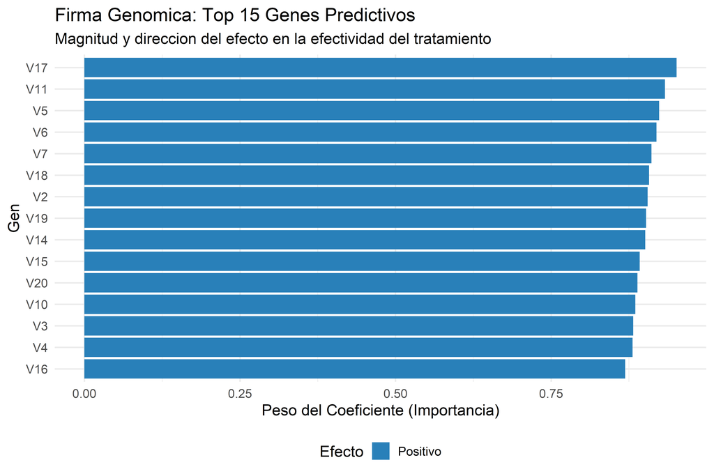

```r
#  Visualización de Importancia de Variables
coef_final <- coef(modelo_final, s = lambda_seleccionado)
importancia <- as.matrix(coef_final)
df_coef <- data.frame(Gen = rownames(importancia), Coeficiente = as.numeric(importancia))

# Filtrar ceros y el intercepto
df_coef <- df_coef %>%
  filter(Gen != "(Intercept)" & Coeficiente != 0) %>%
  mutate(AbsCoef = abs(Coeficiente),
         Efecto = ifelse(Coeficiente > 0, "Positivo", "Negativo")) %>%
  arrange(desc(AbsCoef)) %>%
  head(15) # Tomar el Top 15

# Gráfico de barras horizontales
ggplot(df_coef, aes(x = reorder(Gen, AbsCoef), y = Coeficiente, fill = Efecto)) +
  geom_col() +
  coord_flip() +
  scale_fill_manual(values = c("Positivo" = "#2980b9", "Negativo" = "#c0392b")) +
  theme_minimal(base_size = 14) +
  labs(title = "Firma Genomica: Top 15 Genes Predictivos",
       subtitle = "Magnitud y direccion del efecto en la efectividad del tratamiento",
       x = "Gen", y = "Peso del Coeficiente (Importancia)") +
  theme(legend.position = "bottom")
```